# Maiores remunerações pagas pelos MP’s

## Objetivo

Fazer um levantamento nos dados de Ministérios Públicos monitorados pelo DadosJusBr, pegando os 50 maiores pagamentos feitos a órgãos do MP.

## Detalhes dos 50 maiores pagamentos

**Planilha com relação das remunerações**

[Clique aqui](https://docs.google.com/spreadsheets/d/17xSfvRDoCbiqniphfIExJr4MBlL_JvZPco8rS-teDGo/edit#gid=1085585379) para ver a planilha com os 50 maiores pagamentos feitos aos membros dos MP’s

## Órgãos monitorados

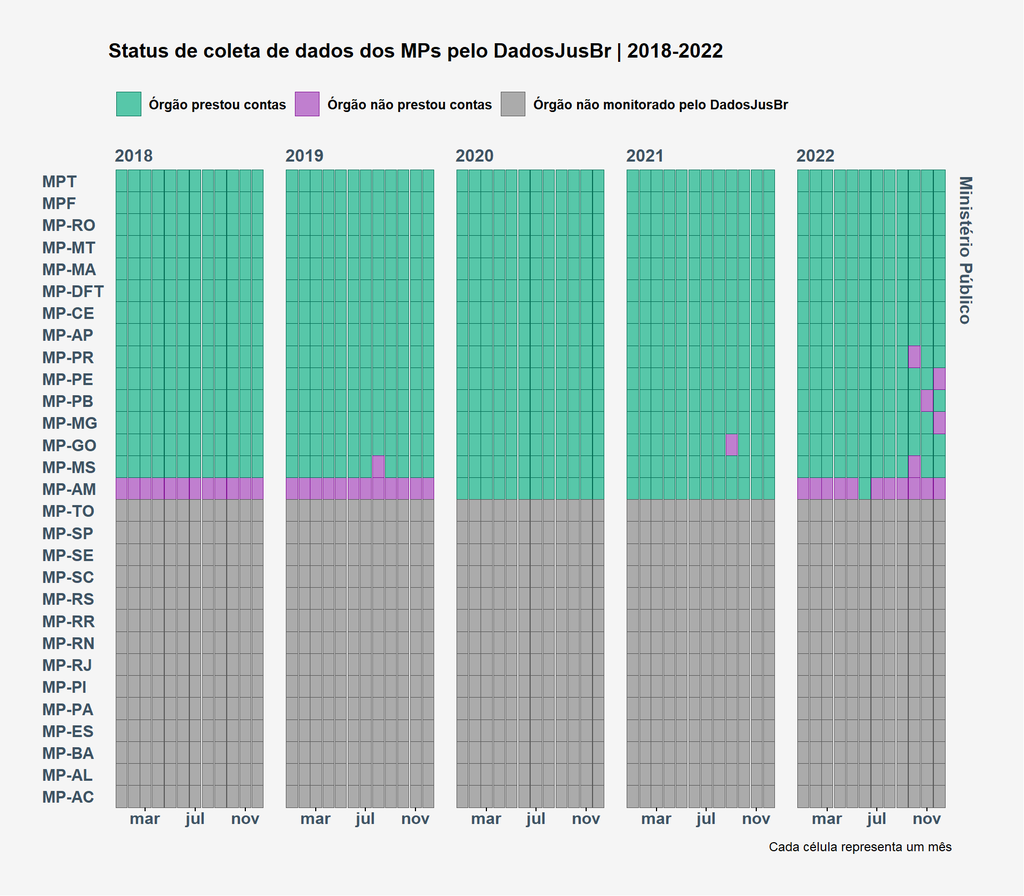

## 15 Maiores remunerações nos MPs

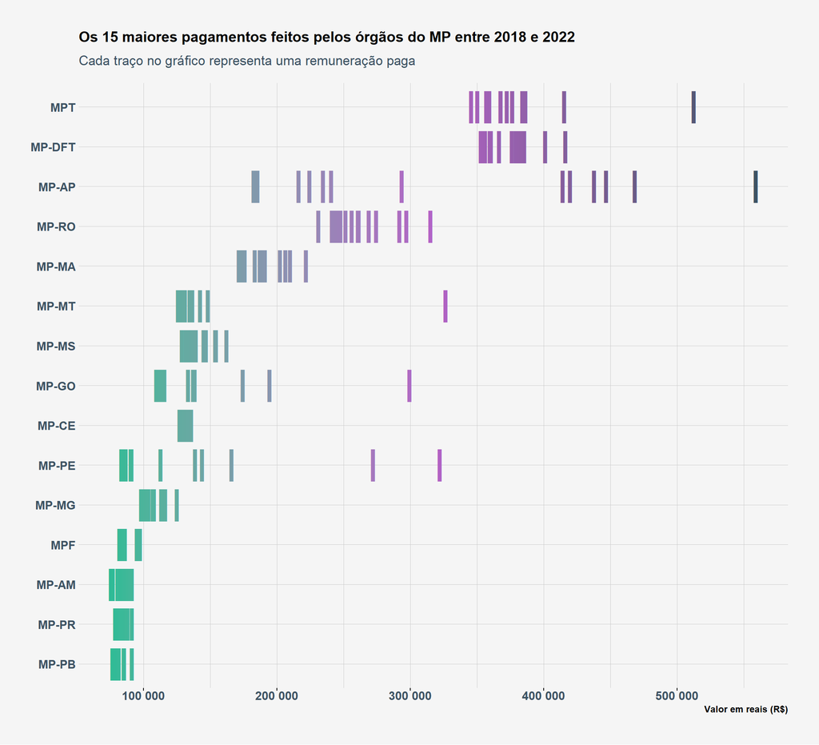

## Órgãos não monitorados pelo DadosJusBr

- mprn - Ministério Público do Rio Grande do Norte:
  - URLs dos arquivos publicados não possuem padrão mínimo e lógico
- mpes - Ministério Público do Estado do Espírito Santo:
  - Estrutura das planilhas sofre mudanças frequentes mês a mês
- mprr - Ministério Público do Estado de Roraima:
  - Não há dados abertos disponíveis
- mpal - Ministério Público do Estado de Alagoas:
  - URLs dos arquivos publicados não possuem padrão mínimo e lógico
- mprs - Ministério Público do Estado do Rio Grande do Sul:
  - Estrutura das planilhas sofre mudanças frequentes mês a mês
  - Planilhas inconsistentes
- mppi - Ministério Público do Piauí:
  - Estrutura das planilhas sofre mudanças frequentes mês a mês
  - URLs dos arquivos publicados não possuem padrão mínimo e lógico
- mpse - Ministério Público de Sergipe:
  - Estrutura das planilhas sofre mudanças frequentes mês a mês
  - URLs dos arquivos publicados não possuem padrão mínimo e lógico
- mpto - Ministério Público do Estado do Tocantins:
  - URLs dos arquivos publicados não possuem padrão mínimo e lógico
- mprj - Ministério Público do Estado do Rio de Janeiro:
  - Estrutura das planilhas sofre mudanças frequentes mês a mês
- mppa - Ministério Público do Estado do Pará:
  - Não publica detalhes das verbas indenizatórias, gratificações e demais verbas
- mpsc - Ministério Público do Estado de Santa Catarina:
  - Estrutura das planilhas sofre mudanças frequentes mês a mês
- mpac - Ministério Público do Estado do Acre:
  - Estrutura das planilhas sofre mudanças frequentes mês a mês
- mpsp - Ministério Público do Estado de São Paulo:
  - Estrutura das planilhas sofre mudanças frequentes mês a mês
  - URLs dos arquivos publicados não possuem padrão mínimo e lógico
- mpba - Ministério Público da Bahia:
  - URLs dos arquivos publicados não possuem padrão mínimo e lógico